# EDA PD3/4 - Podsumowanie

Antoni Szustakowski

05.04.2021

# Wstęp

Celem tej pracy było sprawdzenie, czy i jakie różnice występuja w analizowaniu różnych typów wykresów wśród zwykłych osób. Do badań wygenerowałem przypadkowe dane, bez powiązania z żadnym kontestem, co obrazuje poniższa tabela.

```
##    Nazwa Wartosci Procenty Stosunek_procentowy
## 1 Dane 1    17900 21.51779                  95
## 2 Dane 2     9717 11.68091                  51
## 3 Dane 3    12170 14.62969                  64
## 4 Dane 4    14000 16.82955                  74
## 5 Dane 5    10500 12.62216                  56
## 6 Dane 6    18900 22.71990                 100
```

## Wizualizacje

Kolumnę z procentowym udziałem przedstawiłem na 3 różnych wykresach: kołowym 3D, kołowym 2D, słupkowym.

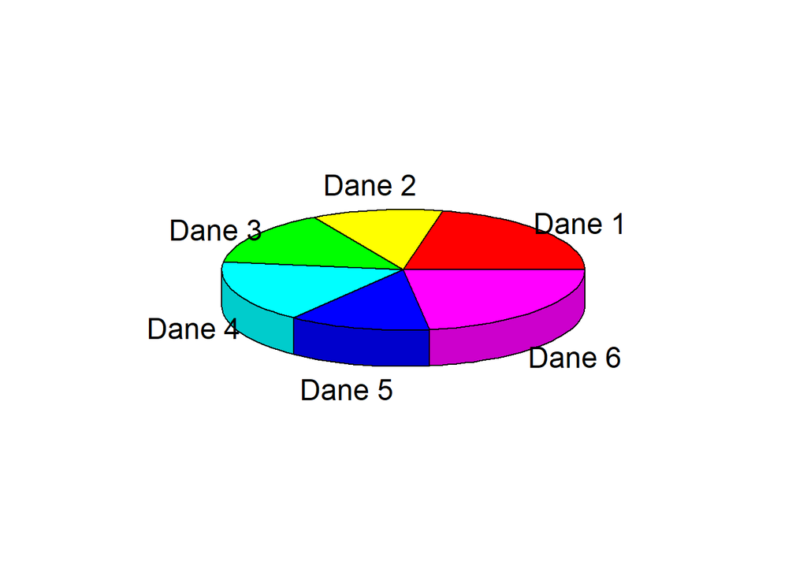

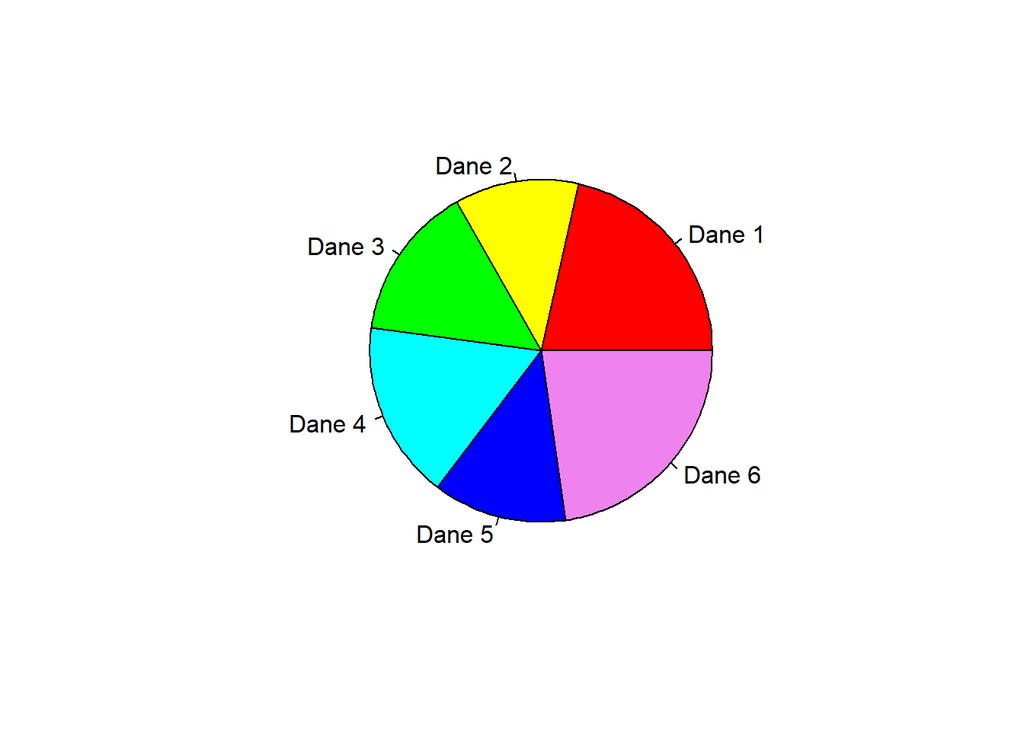

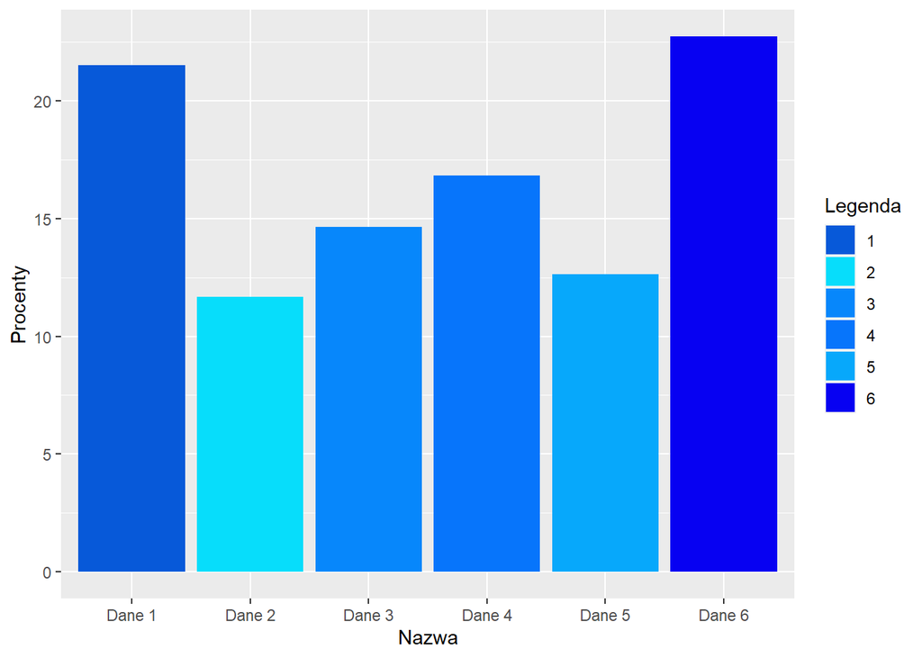

# Badanie

W ramach ankiety zadałem 4 pytania do każdego z wykresów. Poprosiłem o wskazanie: wartości największej, wartości najmniejszej, wartości trzeciej co do wielkości oraz procentowego udziału wartości najmniejszej w największej. Do tych pytań można było udzielić jednej odpowiedzi 1-6 lub “Nie ma takiej wartości”. Ostatnie pytanie dotyczyło uszeregowania typów wykresów w zależności od przejrzystości. Dla tego pytania widełki procentowe ustaliłem następująco: (<50, 50-60, 60-70, 70-80, 80-90, 90-100) W celu utrudnienia zadania dla pytania o procentowy udział dla wykresu słupkowego nie udostępniłem osi prezentującej wysokość słupków.

# Wyniki

Wyniki eksperymentu przedstawiam dla każdego pytania i dla każdego wykresu osobno.

## Wartość największa (6)

```
##             Odpowiedź 3D Częstość 3D
## 1                      1           4
## 2                      6           8
## 3 Nie ma takiej wartości           3
```

```
##             Odpowiedź 2D Częstość 2D
## 1                      1           3
## 2                      6          11
## 3 Nie ma takiej wartości           1
```

```
##   Odpowiedź słupki Częstość słupki
## 1                6              15
```

Z powyższych tabel wynika, że w większość udzieliła poprawnej odpowiedzi (6) dla każdego z wykresów.

## Wartość najmniejsza (2)

```
##             Odpowiedź 3D Częstość 3D
## 1                      2           8
## 2                      5           4
## 3 Nie ma takiej wartości           3
```

```
##             Odpowiedź 2D Częstość 2D
## 1                      2           9
## 2                      5           5
## 3 Nie ma takiej wartości           1
```

```
##   Odpowiedź słupki Częstość słupki
## 1                2              15
```

Dla wartości najmniejszej większość odpowiedzi również była poprawna.

## Wartość trzecia (4)

```
##             Odpowiedź 3D Częstość 3D
## 1                      3           3
## 2                      4           8
## 3 Nie ma takiej wartości           4
```

```
##   Odpowiedź 2D Częstość 2D
## 1            2           1
## 2            3           3
## 3            4          11
```

```
##   Odpowiedź słupki Częstość słupki
## 1                3               4
## 2                4              11
```

Tutaj ponownie, większość odpowiedzi jest poprawna. Kilka niepoprawnych odpowiedzi dla wykresu słupkowego może wynikać z niezrozumienia pytanie (trzecia najmniejsza zamiast trzecia największa).

```
##   Odpowiedź 3D Częstość 3D
## 1        50-60          10
## 2        60-70           3
## 3 mniej niż 50           2
```

```
##   Odpowiedź 2D Częstość 2D
## 1        50-60          10
## 2        60-70           1
## 3 mniej niż 50           4
```

```
##   Odpowiedź słupki Częstość słupki
## 1            50-60               8
## 2            60-70               1
## 3            70-80               1
## 4     mniej niż 50               5
```

W tym przypadku tak samo większość ankietowanych odpowiedziała poprawnie.

## Ulubiony wykres

```
## # A tibble: 2 x 2
##   Ranking                                   n
##   <chr>                                 <int>
## 1 1. Kołowy 2D 2. Słupkowy 3. Kołowy 3D     1
## 2 1. Słupkowy 2. Kołowy 2D 3. Kołowy 3D    14
```

O ile w przypadku udzielanych odpowiedzi dla wszystkich wykresów większość osób odpowiadała prawidłowo, to jednak preferowany typ wykresu jest zdecydowanie jeden.

# Podsumowanie

## Poprawność

Sprawdziłem, czy jest jakaś zależność pomiędzy typem wykresu a poprawnością udzielanych odpowiedzi. Przedstawione zostało to na poniższym wykresie:

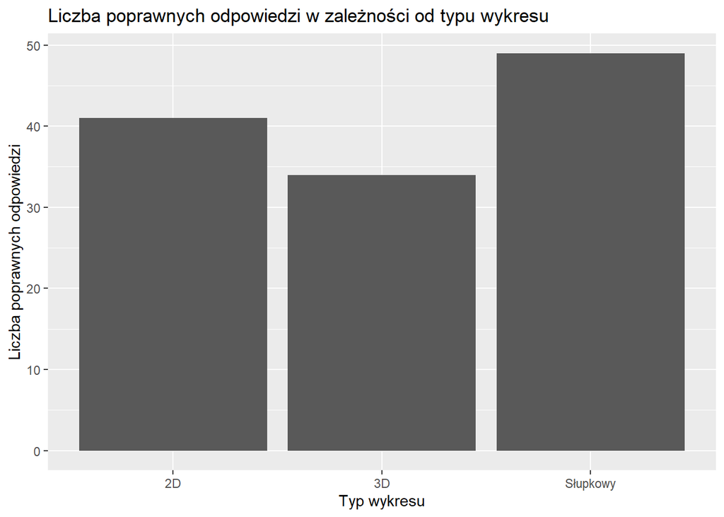

Zatem zdecydowanie najwięcej poprawnych odpowiedzi zostało udzielonych przy pytaniach dla wykresu słupkowego, a najmniej dla wykresu kołowego 3D. Natomiast wykres kołowy 2D wypadł powyżej moich oczekiwań, spodziewałem się więcej błędnych odpowiedzi.

## Popularność

Zarówno w ankiecie, jak i w wiadomościach prywatnych otrzymałem wiele odpowiedzi wskazujących na to, że wykres kołowy 3D jest najbardziej wymagający do odczytania, a wykres słupkowy najprzyjemniejszy. Sporo osób wysilało się przy odczytywaniu danych z wykresu kołowego, natomiast wykres słupkowy (co jest widoczne w odpowiedziach) nie był wymagający.

## Typy poprawnych odpowiedzi

Przy porównywaniu wielkościowym wykres słupkowy zdominował konkurencję, natomiast wykresy kołowe okazały się nie aż tak niemożliwe do odczytania, jak mi się początkowo zdawało. Być może zwiększenie liczby danych wprowadziłoby większy chaos. Zasakujące dla mnie było, że przy wykresie słupkowym pojawiły się problemy z porównaniem procentowym długości najmniejszej i największej wartości. Być może wynikało to z zbytniego skomplikowania pytania (otrzymałem taką odpowiedź prywatnie).

## Ogólne podsumowanie

Zdecydowanie najlepszym wykresem pod względem poprawnych odpowiedzi i łatwości w odczytaniu jest wykres słupkowy. Wykresy kołowe są dużo bardziej wymagające do porównywania wielkości, jeśli nie doda się podpisanych wartości. Zatem wieloletnie “dobre praktyki” się w tym badaniu potwierdziły - słupki są przystępniejsze od kątów.